# Practical Machine Learning Project

Manuel Ventero

2 March 2017

# Introduction

Using devices such as Jawbone Up, Nike FuelBand, and Fitbit it is now possible to collect a large amount of data about personal activity relatively inexpensively. These type of devices are part of the quantified self movement - a group of enthusiasts who take measurements about themselves regularly to improve their health, to find patterns in their behavior, or because they are tech geeks. One thing that people regularly do is quantify how much of a particular activity they do, but they rarely quantify how well they do it. In this project, your goal will be to use data from accelerometers on the belt, forearm, arm, and dumbell of 6 participants. They were asked to perform barbell lifts correctly and incorrectly in 5 different ways. More information is available from the website here: [http://groupware.les.inf.puc-rio.br/har]http://groupware.les.inf.puc-rio.br/har (see the section on the Weight Lifting Exercise Dataset).

# Data processing

```r
library(RCurl)
library(xgboost)
library(dplyr)
library(caret)
library(reshape2)
library(ggplot2)


if (!file.exists("./data")) {
  dir.create("./data")
}
if (!file.exists("./data/pml-training.csv")) {
  url.training <- "https://d396qusza40orc.cloudfront.net/predmachlearn/pml-training.csv"
  download.file(url.training, destfile = "./data/pml-training.csv")
}

if (!file.exists("./data/pml-testing.csv")) {
  url.testing <- "https://d396qusza40orc.cloudfront.net/predmachlearn/pml-testing.csv"
  download.file(url.testing, destfile = "./data/pml-testing.csv")
}

train <- read.csv("data/pml-training.csv")
test <- read.csv("data/pml-testing.csv")
dim(train); dim(test)
```

```
## [1] 19622   160
```

```
## [1]  20 160
```

## Preprocessing

Multiple preprocessing techniques have been applied on the data.

First, variables with near zero variance were removed. Right after that, variables with more than 75% percent pearson correlation, we also removed.

No linear combinations of variables were found.

```r
set.seed(12345)

x <- train[,-c(160)]
y <- train[,c(160)]

xNonNumeric <- grepl("^X|timestamp|window", names(x))
x <- x[, !xNonNumeric]

nzv <- nearZeroVar(x)
xnzv <- x[, -nzv]

xnarep <- xnzv[, colSums(is.na(xnzv)) == 0]
xnarep <- xnarep[, sapply(xnarep, is.numeric)]

highlyCorDescr <- findCorrelation(cor(xnarep), cutoff = .75)
xncor <- xnarep[,-highlyCorDescr]

comboInfo <- findLinearCombos(xncor)

if(!is.null(comboInfo$remove)){
  print("Removing linear combos")
  xfinal <- xncor[, -comboInfo$remove]
}else{
  print("no combos found")
  xfinal <- xncor
}
```

```
## [1] "no combos found"
```

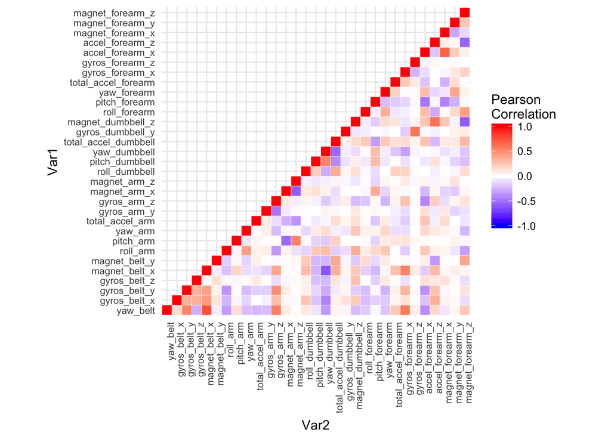

```r
cormat <- round(cor(xfinal),2)
melted_cormat <- melt(cormat)

# Get lower triangle of the correlation matrix
get_lower_tri<-function(cormat){
  cormat[upper.tri(cormat)] <- NA
  return(cormat)
}
# Get upper triangle of the correlation matrix
get_upper_tri <- function(cormat){
  cormat[lower.tri(cormat)]<- NA
  return(cormat)
}

reorder_cormat <- function(cormat){
  # Use correlation between variables as distance
  dd <- as.dist((1-cormat)/2)
  hc <- hclust(dd)
  cormat <-cormat[hc$order, hc$order]
}

upper_tri <- get_upper_tri(cormat)
# Melt the correlation matrix
melted_cormat <- melt(upper_tri, na.rm = TRUE)
# Create a ggheatmap
ggheatmap <- ggplot(melted_cormat, aes(Var2, Var1, fill = value))+
 geom_tile(color = "white")+
 scale_fill_gradient2(low = "blue", high = "red", mid = "white",
   midpoint = 0, limit = c(-1,1), space = "Lab",
    name="Pearson\nCorrelation") +
  theme_minimal()+ # minimal theme
 theme(axis.text.x = element_text(angle = 90, vjust = 1,
    size = 8, hjust = 1), axis.text.y = element_text(size = 8))+
 coord_fixed()
# Print the heatmap
print(ggheatmap)
```

## Data splitting

```r
colnames(xfinal)
```

```
##  [1] "yaw_belt"             "gyros_belt_x"         "gyros_belt_y"
##  [4] "gyros_belt_z"         "magnet_belt_x"        "magnet_belt_y"
##  [7] "roll_arm"             "pitch_arm"            "yaw_arm"
## [10] "total_accel_arm"      "gyros_arm_y"          "gyros_arm_z"
## [13] "magnet_arm_x"         "magnet_arm_z"         "roll_dumbbell"
## [16] "pitch_dumbbell"       "yaw_dumbbell"         "total_accel_dumbbell"
## [19] "gyros_dumbbell_y"     "magnet_dumbbell_z"    "roll_forearm"
## [22] "pitch_forearm"        "yaw_forearm"          "total_accel_forearm"
## [25] "gyros_forearm_x"      "gyros_forearm_z"      "accel_forearm_x"
## [28] "accel_forearm_z"      "magnet_forearm_x"     "magnet_forearm_y"
## [31] "magnet_forearm_z"
```

```r
test_prep<- test[,colnames(xfinal)]
test_prep <- test_prep[, colSums(is.na(test_prep)) == 0]
test_prep <- test_prep[, sapply(test_prep, is.numeric)]

df_final <- xfinal
df_final['y'] <- y

inTrain <- createDataPartition(df_final$y, p=0.70, list=F)
train_data <- df_final[inTrain, ]
test_data <- df_final[-inTrain, ]
```

## Modeling

### Model 1. Random Forest

```r
library(doMC)
registerDoMC(cores = 4)

setting <- trainControl(method="cv", 3, allowParallel = TRUE)

modRF <- train(y ~ ., data=train_data, method="rf", trControl=setting, ntree=250)
```

```r
modRF
```

```
## Random Forest
##
## 13737 samples
##    31 predictor
##     5 classes: 'A', 'B', 'C', 'D', 'E'
##
## No pre-processing
## Resampling: Cross-Validated (3 fold)
## Summary of sample sizes: 9158, 9159, 9157
## Resampling results across tuning parameters:
##
##   mtry  Accuracy   Kappa
##    2    0.9865331  0.9829617
##   16    0.9856595  0.9818582
##   31    0.9797634  0.9743979
##
## Accuracy was used to select the optimal model using  the largest value.
## The final value used for the model was mtry = 2.
```

```r
modRF$finalModel
```

```
##
## Call:
##  randomForest(x = x, y = y, ntree = 250, mtry = param$mtry)
##                Type of random forest: classification
##                      Number of trees: 250
## No. of variables tried at each split: 2
##
##         OOB estimate of  error rate: 0.89%
## Confusion matrix:
##      A    B    C    D    E class.error
## A 3901    2    1    1    1 0.001280082
## B   20 2632    6    0    0 0.009781791
## C    0   28 2351   16    1 0.018781302
## D    0    0   39 2210    3 0.018650089
## E    0    0    0    4 2521 0.001584158
```

```r
classe <- predict(modRF, newdata=test_data)
classeConfusionMatrix <- confusionMatrix(classe, test_data$y)
classeConfusionMatrix
```

```
## Confusion Matrix and Statistics
##
##           Reference
## Prediction    A    B    C    D    E
##          A 1672   12    0    0    0
##          B    2 1121   20    0    0
##          C    0    6  999   24    0
##          D    0    0    7  940    3
##          E    0    0    0    0 1079
##
## Overall Statistics
##
##                Accuracy : 0.9874
##                  95% CI : (0.9842, 0.9901)
##     No Information Rate : 0.2845
##     P-Value [Acc > NIR] : < 2.2e-16
##
##                   Kappa : 0.9841
##  Mcnemar's Test P-Value : NA
##
## Statistics by Class:
##
##                      Class: A Class: B Class: C Class: D Class: E
## Sensitivity            0.9988   0.9842   0.9737   0.9751   0.9972
## Specificity            0.9972   0.9954   0.9938   0.9980   1.0000
## Pos Pred Value         0.9929   0.9808   0.9708   0.9895   1.0000
## Neg Pred Value         0.9995   0.9962   0.9944   0.9951   0.9994
## Prevalence             0.2845   0.1935   0.1743   0.1638   0.1839
## Detection Rate         0.2841   0.1905   0.1698   0.1597   0.1833
## Detection Prevalence   0.2862   0.1942   0.1749   0.1614   0.1833
## Balanced Accuracy      0.9980   0.9898   0.9838   0.9865   0.9986
```

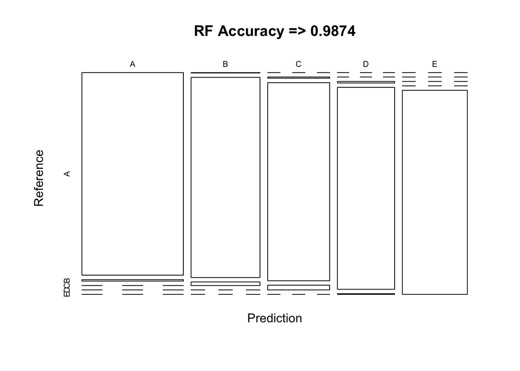

```r
# plot matrix results
plot(classeConfusionMatrix$table, col = classeConfusionMatrix$byClass,
     main = paste("RF Accuracy =>",
                  round(classeConfusionMatrix$overall['Accuracy'], 4)))
```

Random Forest model has a 0.9874 performance.

### Model 2. Gradient Boosting (Xgboost package)

```r
train_data_x = train_data[, -which(names(train_data) == "y")]
train_data_y = as.character(train_data$y)

train_data_y[train_data_y=='A'] <- '0'
train_data_y[train_data_y=='B'] <- '1'
train_data_y[train_data_y=='C'] <- '2'
train_data_y[train_data_y=='D'] <- '3'
train_data_y[train_data_y=='E'] <- '4'
train_data_y = as.numeric(train_data_y)

test_data_x = test_data[, -which(names(test_data) == "y")]
test_data_y = as.character(test_data$y)
test_data_y[test_data_y=='A'] <- '0'
test_data_y[test_data_y=='B'] <- '1'
test_data_y[test_data_y=='C'] <- '2'
test_data_y[test_data_y=='D'] <- '3'
test_data_y[test_data_y=='E'] <- '4'
test_data_y = as.numeric(test_data_y)

train_matrix <- xgb.DMatrix(as.matrix(train_data_x), label=train_data_y, missing=NaN)
test_matrix <- xgb.DMatrix(as.matrix(test_data_x), label=test_data_y, missing=NaN)

noClasses <- length(unique(df_final$y))

modXgboostParamas <- list("objective" = "multi:softprob",
                   "eval_metric" = "mlogloss",
                   "num_class" = noClasses)
nround    <- 300 # number of XGBoost rounds
# Fit cv.nfold * cv.nround XGB models and save OOF predictions
modXgboost <- xgb.train(params = modXgboostParamas,
                       data = train_matrix,
                       nrounds = nround)
```

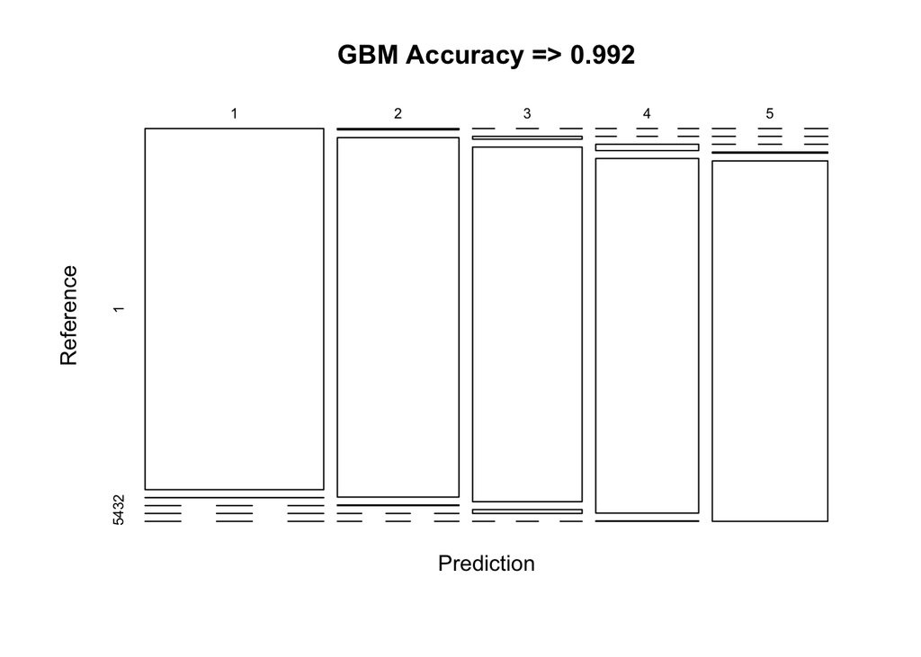

```r
# Predict hold-out test set
test_pred <- predict(modXgboost, newdata = test_matrix)
test_prediction <- matrix(test_pred, nrow = noClasses,
                          ncol=length(test_pred)/noClasses) %>%
  t() %>%
  data.frame() %>%
  mutate(label = test_data_y + 1,
         max_prob = max.col(., "last"))
# confusion matrix of test set
classeConfusionMatrixGBM <- confusionMatrix(factor(test_prediction$label),
                factor(test_prediction$max_prob),
                mode = "everything")

plot(classeConfusionMatrixGBM$table, col = classeConfusionMatrixGBM$byClass,
     main = paste("GBM Accuracy =>",
                  round(classeConfusionMatrixGBM$overall['Accuracy'], 4)))
```

```r
xgb_final <- predict(modXgboost, newdata = as.matrix(test_prep))


df_xgb_final <- matrix(xgb_final, nrow = noClasses,
                          ncol=length(xgb_final)/noClasses) %>%
  t() %>%
  data.frame() %>%
  mutate(max_prob = max.col(., "last"))
```

Gradient boosting model has a 0.992 performance.

### Modeling Conclusion

Gradient boosting outperforms random forest, thus we will use it to predict the final class result.

# Final prediction

```r
predRF <- predict(modRF, newdata=test_prep)
predXgb <- df_xgb_final$max_prob
predXgb = as.character(predXgb)
predXgb[predXgb=='1'] <- 'A'
predXgb[predXgb=='2'] <- 'B'
predXgb[predXgb=='3'] <- 'C'
predXgb[predXgb=='4'] <- 'D'
predXgb[predXgb=='5'] <- 'E'

df_results <- data.frame(rf = predRF, xgb = predXgb)
df_results['equal'] <- df_results['rf'] == df_results['xgb']

df_results
```

```
##    rf xgb   rf
## 1   B   B TRUE
## 2   A   A TRUE
## 3   B   B TRUE
## 4   A   A TRUE
## 5   A   A TRUE
## 6   E   E TRUE
## 7   D   D TRUE
## 8   B   B TRUE
## 9   A   A TRUE
## 10  A   A TRUE
## 11  B   B TRUE
## 12  C   C TRUE
## 13  B   B TRUE
## 14  A   A TRUE
## 15  E   E TRUE
## 16  E   E TRUE
## 17  A   A TRUE
## 18  B   B TRUE
## 19  B   B TRUE
## 20  B   B TRUE
```